# Analysis of the Dallas Crime Dataset using Logistic Regressions, SVMs, and Gradient Optomization

### MSDS 7331 Data Mining: MiniProject

#### By Jean Jecha, Sharon Teo, Jessica Wheeler

## Introduction

In our previous project, we explored the Dallas Crime Dataset to find out what types of crimes happened in Dallas in 2016 to possibly identify trouble areas that the Dallas PD can focus their resources on. In taking a look at the crimes, we found that theft, followed by burglary and criminal mischief/vandalism were the highest occurring crimes in Dallas in 2016. Then we looked at when these crimes occurred and found that the month of May had the highest number of incidents as well as Fridays. As location is critical as well, our results showed that the NorthEast Division saw the most occurrences. We also looked into victim conditions as those indicate the most dangerous type of crimes- violent crimes- and found that the North Central Division had the highest rate of victim deaths at 19%. Lastly, we looked at how long it took police to resolve crimes by looking at the end time minus the start time of the occurrences in the dataset. Our results were that theft and burglary took the longest to resolve. We will now dive into using Logistic Regression, Support Vector Machines (SVMs), and Gradient Optimization techniques to elicit the factors that affect the time when a call is received to the time units are dispatched.

## Analysis

We orginally wanted to see how long it takes an officer to arrive at a scene after being dispatched but the arrival time is not included in the dataset. Thus, we decided on focusing on the amount of time between when a call is received to when officers are dispatched and using the techniques mentioned above to see what factors affect this time. We chose to focus on the variables Watch, Penalty Class, Division, Time of Occurrence, Month of the Year, Day of the Week, Gang Related Offence, and Drug Related Incident to contemplate the following questions:

- Are units dispatched out faster when the crime ends up being classified as a felony versus a misdemeanor?
- Does the time of the week or the time of the year have an effect on these times?
- Is this time consistently slower for certain divisions than others?
- How about which watch or shift the crimes occur?
- Are dispatch times faster for gang and/or drug related activities?

We decided on a threshold of 30 minutes or less being "fast" and 30+ minutes being "slow" dispatch time. We specifically looked at what factors contribute to the dispatch time being slow as those can be areas of improvement and focus for the Dallas PD. We begin our analysis of further cleaning the dataset, removing variables that we are not focusing on, and creating new and more specific subsets of variables.

## Contents

- Loading the Data
- Cleaning the Data
- Training and Testing Split
- Logistic Regression
- Interpreting Weights
- Support Vector Machines (SVMs)
- Gradient Based Alternatives
- Conclusion

Back to Top

## Loading the Data

```python
# Import Crime data set
# Orginal dataset froms https://www.dallasopendata.com/Public-Safety/Police-Incidents/tbnj-w5hbhttp
import pandas as pd
import numpy as np
import seaborn as sns
%matplotlib inline
import matplotlib.pyplot as plt
from __future__ import print_function

# read in the csv file
df = pd.read_csv('data/Police_Incidents.csv')

# Reference: http://stackoverflow.com/questions/11346283/renaming-columns-in-pandas
# Removing spaces from headers

df.columns = [x.strip().replace(' ', '') for x in df.columns]
df.columns = [x.strip().replace('/', '') for x in df.columns]
df.columns = [x.strip().replace('(', '') for x in df.columns]
df.columns = [x.strip().replace(')', '') for x in df.columns]
df.columns = [x.strip().replace('-', '') for x in df.columns]

df.head()
```

|  | IncidentNumberwYear | YearofIncident | IncidentNumberwoYear | OffenseServiceNumber | ServiceNumberID | Watch | Call911Problem | TypeofIncident | PenaltyClass | TypeofLocation | ... | UCROffenseName | UCROffenseDescription | OffenseType | ModusOperandiMO | FamilyOffense | HateCrime | GangRelatedOffense | VictimPackage | DrugRelatedIncident | UpdateDate |
| --- | --- | --- | --- | --- | --- | --- | --- | --- | --- | --- | --- | --- | --- | --- | --- | --- | --- | --- | --- | --- | --- |
| 0 | 000003-2017 | 2017 | 3 | 000003E | 000003-2017-01 | 3 | 07 - MINOR ACCIDENT | UCR - ASSAULT (AGG) M/V | NaN | Highway, Street, Alley ETC | ... | VANDALISM & CRIM MISCHIEF | CRIMINAL MISCHIEF/VANDALISM | PART2 | A/P INTENTIONALLY STRUCK COMP'S VEHICLE WITH H... | No | NaN | UNK | NaN | UNK | 01/09/2017 02:10:32 PM |
| 1 | 000003-2017 | 2017 | 3 | 000003E | 000003-2017-02 | 3 | 07 - MINOR ACCIDENT | UCR - ASSAULT (AGG) M/V | NaN | Highway, Street, Alley ETC | ... | VANDALISM & CRIM MISCHIEF | CRIMINAL MISCHIEF/VANDALISM | PART2 | A/P INTENTIONALLY STRUCK COMP'S VEHICLE WITH H... | No | NaN | UNK | NaN | UNK | 01/09/2017 02:10:32 PM |
| 2 | 000003-2017 | 2017 | 3 | 000003E | 000003-2017-03 | 3 | 07 - MINOR ACCIDENT | UCR - ASSAULT (AGG) M/V | NaN | Highway, Street, Alley ETC | ... | VANDALISM & CRIM MISCHIEF | CRIMINAL MISCHIEF/VANDALISM | PART2 | A/P INTENTIONALLY STRUCK COMP'S VEHICLE WITH H... | No | NaN | UNK | NaN | UNK | 01/09/2017 02:10:32 PM |
| 3 | 001455-2017 | 2017 | 1455 | 001455E | 001455-2017-01 | U | 58 - ROUTINE INVESTIGATION | CRIM MISCHIEF >OR EQUAL $100 BUT <$750 | MB | Apartment Parking Lot | ... | VANDALISM & CRIM MISCHIEF | CRIMINAL MISCHIEF/VANDALISM | PART2 | UNKNOWN SUSPECT DAMAGED COMP PROPERTY | No | NaN | UNK | NaN | UNK | 02/07/2017 02:58:11 PM |
| 4 | 000004-2016 | 2016 | 4 | 000004D | 000004-2016-01 | 3 | 09V - UUMV | UNAUTHORIZED USE OF MOTOR VEH - AUTOMOBILE | FS | Highway, Street, Alley ETC | ... | UUMV | AUTO THEFT - UUMV | PART1 | UUMV | No | NaN | No | NaN | No | 04/20/2016 09:00:30 AM |

5 rows × 102 columns

Back to Top

# Cleaning the Data

In our previous analysis, we chose to focus on the year 2016 since that had the most complete data in the dataset. Thus, we will continue to focus on that year and subset the data for 2016. We then removed most of the attributes in the dataset, narrowing down our focus on the few attributes mentioned above.

```python
# Subset the dataset to year 2016
# Ref: http://stackoverflow.com/questions/18172851/deleting-dataframe-row-in-pandas-based-on-column-value

df = df[df.Year1ofOccurrence == 2016]
#list(df)
```

```python
# Narrowing down our focus to the attributes mentioned in the Dataset
# description by removing columns not used in analysis

for col in ['OffenseServiceNumber','ServiceNumberID','ReportingArea','Beat','Sector','CouncilDistrict',
            'DPDSwornMarshallsinvolved','ComplainantHomeAddress','ComplainantApartment','ComplainantZipCode',
            'ComplainantCity','ComplainantState','ComplainantBusinessName','ComplainantBusinessAddress',
            'YearAssignment','Weather','RespondingOfficer#1BadgeNo','RespondingOfficer#1Name','RespondingOfficer#2BadgeNo',
            'RespondingOfficer#2Name','ReportingOfficerBadgeNo','AssistingOfficerBadgeNo','ReviewingOfficerBadgeNo',
            'ElementNumberAssigned','InvestigatingUnit1','InvestigatingUnit2','SpecialReportPreRMS','UCRDisposition',
            'UCR1','UCR2PreRMS','FinalUCR','RMSCode','CJISCode','PenalCode','HateCrime','VictimPackage', 'UpdateDate',
            'ModusOperandiMO', 'OffenseCodeCC', 'VictimInjuryDescription', 'OffenseStatus',
            'ComplainantAgeatOffense', 'ComplainantAge', 'ComplainantGender', 'ComplainantRace', 'ComplainantName',
           'OffenseEnteredDateTime', 'OffenseEnteredTime', 'OffenseEnteredDayoftheWeek', 'OffenseEnteredMonth',
            'OffenseEnteredYear', 'Dateincidentcreated', 'MapDate', 'Day2oftheYear','IncidentNumberwoYear', 'YearofIncident',
           'IncidentNumberwYear', 'Call911Problem', 'StreetBlock', 'StreetDirection', 'StreetName',
           'IncidentAddress', 'ApartmentNumber', 'ZipCode', 'City', 'State', 'TargetAreaActionGrids',
           'Community', 'Date1ofOccurrence', 'Date2ofOccurrence', 'Year2ofOccurrence', 'Month2ofOccurence', 'Day2oftheWeek',
            'Time2ofOccurrence', 'StartingDateTime', 'EndingDateTime', 'DateofReport','CallDateTime',
            'TypeofProperty', 'IncidentNumberwYear', 'Year1ofOccurrence', 'Day1oftheYear', 'TypeofIncident','UCROffenseName',
           'OffenseType','FamilyOffense','PersonInvolvementType','TypeofLocation','VictimCondition','UCROffenseDescription']:
    if col in df:
        del df[col]

#Let's get the specs of our subsetted data:
print (df.info())
```

```
<class 'pandas.core.frame.DataFrame'>
Int64Index: 99341 entries, 0 to 196036
Data columns (total 13 columns):
Watch                   99341 non-null object
PenaltyClass            84593 non-null object
XCoordinate             97393 non-null float64
YCoordinate             97393 non-null float64
Division                99321 non-null object
Month1ofOccurence       99341 non-null object
Day1oftheWeek           99341 non-null object
Time1ofOccurrence       99341 non-null object
CallReceivedDateTime    99328 non-null object
CallClearedDateTime     99310 non-null object
CallDispatchDateTime    99319 non-null object
GangRelatedOffense      99339 non-null object
DrugRelatedIncident     99339 non-null object
dtypes: float64(2), object(11)
memory usage: 10.6+ MB
None
```

We see that there are some missing variables above - in `PenaltyClass`, `Divison`, `CallReceivedDateTime`, `CallClearedDateTime`, and `CallDispatchedDateTime`. We will impute these variables but first we will convert time Call times into datetimes so they are treated as so and not objects.

```python
# Convert to date and time fields
# Note: Takes long to run, might be a quicker method to do this conversion
# Reference: http://stackoverflow.com/questions/16852911/how-do-i-convert-dates-in-a-pandas-data-frame-to-a-date-data-type
df['CallReceivedDateTime'] = pd.to_datetime(df['CallReceivedDateTime'])
df['CallClearedDateTime'] = pd.to_datetime(df['CallClearedDateTime'])
df['CallDispatchDateTime'] = pd.to_datetime(df['CallDispatchDateTime'])
```

The categorical variables we are interested in are `PenaltyClass`, `Month1ofOccurrence`, `Watch`, and `Division`. The table below shows how many specific categories can be created from each attribute as well as the top value and the frequencies of that value. This information will be useful when we impute and transform the data.

```python
# Checking number of unique and top values
df[['Month1ofOccurence', 'PenaltyClass', 'Watch', 'Division']].describe().transpose()
```

|  | count | unique | top | freq |
| --- | --- | --- | --- | --- |
| Month1ofOccurence | 99341 | 12 | May | 8737 |
| PenaltyClass | 84593 | 11 | MB | 22437 |
| Watch | 99341 | 4 | 1 | 32189 |
| Division | 99321 | 7 | NorthEast | 17583 |

Below we computed the time between call received and call dispatched, removed rows with negative time difference, and converted `Time1ofOccurrence` into hour (from 0-23).

There were multiple types or classes of misdemeanors and felonies so we classified all types of felonies as `F` and all types of misdemeanors as `M`.

Next we created an `"IsWeekend"` category which included Fridays, Saturdays, and Sundays and made those of integer type so the column would have a 1 for those days versus a 0 for Mondays through Thursdays.

To make Gang and Drug related incidents more useful, we used binary encoding as well. Then we deleted the original columns as they are no longer needed.

```python
# Compute the time between call received and call displatched, call Displatch and call cleared.
# Reference: http://www.itgo.me/a/x791470639852744898/calculate-pandas-dataframe-time-difference-between-two-columns-in-hours-and-minu
df['rec_disp_time_m'] = (df['CallDispatchDateTime'] - df['CallReceivedDateTime']).astype('timedelta64[m]')
df['disp_clear_time_m'] = (df['CallClearedDateTime'] - df['CallDispatchDateTime']).astype('timedelta64[m]')

# Remove rows with negative time difference
df = df[df.disp_clear_time_m >= 0]
df = df[df.rec_disp_time_m >= 0]

# Create Hour of Occurrence from Time Occurrence
# Ref: http://stackoverflow.com/questions/25789445/pandas-make-new-column-from-string-slice-of-another-column
df['Hour'] = df.Time1ofOccurrence.str[:2]
df['Hour'] = (df['Hour']).astype('float64')

# Retrieve first character of penalty class as only F for felony or M misdemeanor
df['Penalty'] = df.PenaltyClass.str[:1]

# Change day of week to indicate weekend
df['IsWeekend'] = (df['Day1oftheWeek'] == 'Sat') | (df['Day1oftheWeek'] == 'Fri') | (df['Day1oftheWeek'] == 'Sun')
df.IsWeekend = df.IsWeekend.astype(np.int)

# change Gang Related attribute to a more usable value
df['IsGangRelated'] = df.GangRelatedOffense == 'Yes'
df.IsGangRelated = df.IsGangRelated.astype(np.int)

# change Drug Related attribute to a more usable value
df['IsDrugRelated'] = df.DrugRelatedIncident == 'Yes'
df.IsDrugRelated = df.IsDrugRelated.astype(np.int)

# Save For joinplots
df_Plot = df[['rec_disp_time_m','XCoordinate','YCoordinate']].copy()

# Remove call datetime call columns
for col in ['CallReceivedDateTime','CallClearedDateTime','CallDispatchDateTime','Time1ofOccurrence',
            'PenaltyClass','Day1oftheWeek','GangRelatedOffense','DrugRelatedIncident','XCoordinate',
            'YCoordinate']:
    if col in df:
        del df[col]

df.head()
```

|  | Watch | Division | Month1ofOccurence | rec_disp_time_m | disp_clear_time_m | Hour | Penalty | IsWeekend | IsGangRelated | IsDrugRelated |
| --- | --- | --- | --- | --- | --- | --- | --- | --- | --- | --- |
| 0 | 3 | Central | December | 0.0 | 207.0 | 23.0 | NaN | 1 | 0 | 0 |
| 1 | 3 | Central | December | 0.0 | 207.0 | 23.0 | NaN | 1 | 0 | 0 |
| 2 | 3 | Central | December | 0.0 | 207.0 | 23.0 | NaN | 1 | 0 | 0 |
| 3 | U | NorthEast | December | 0.0 | 439.0 | 12.0 | M | 0 | 0 | 0 |
| 5 | 3 | SouthEast | December | 3.0 | 122.0 | 23.0 | M | 1 | 0 | 0 |

Any missing values in the dataset were filled in using the imputation methods below. Values were imputed within the grouping of `Month1ofOccurrence` and `Watch`. Numeric values were filled in using the medians of their attributes whereas `Penalty` and `Division` were imputed with the most frequent values occurring for those attributes.

```python
# creating missing values grouping by day of week and watch
df_grouped = df.groupby(by=['Month1ofOccurence','Watch'])

# Using grouping to impute data in each group and then transform back
# Impute missing numerical values
df_imputed = df_grouped.transform(lambda grp: grp.fillna(grp.median()))

# Impute missing categorical values
# Ref: http://stackoverflow.com/questions/32617811/imputation-of-missing-values-for-categories-in-pandas
df_imputed['Penalty'] = df_grouped.Penalty.fillna(df['Penalty'].value_counts().index[0])
df_imputed['Division'] = df_grouped.Division.fillna(df['Division'].value_counts().index[0])

# Filling the grouped variables from original data frame
df_imputed[['Month1ofOccurence','Watch']] = df[['Month1ofOccurence','Watch']]
```

Now let's take a look at our dataset to see if everything was filled in and categorized as we wanted:

```python
df_imputed.info()
```

```
<class 'pandas.core.frame.DataFrame'>
Int64Index: 99296 entries, 0 to 196036
Data columns (total 10 columns):
rec_disp_time_m      99296 non-null float64
disp_clear_time_m    99296 non-null float64
Hour                 99296 non-null float64
IsWeekend            99296 non-null int64
IsGangRelated        99296 non-null int64
IsDrugRelated        99296 non-null int64
Penalty              99296 non-null object
Division             99296 non-null object
Month1ofOccurence    99296 non-null object
Watch                99296 non-null object
dtypes: float64(3), int64(3), object(4)
memory usage: 8.3+ MB
```

We want to look at the categorical variables `Penalty`, `Division`, `Watch`, and `Month1ofOccurrence` and convert those into integers using binary or OneHot Encoding. This will then create more specific categories- for example, `Penalty` will now take on three different values - one for each possible variable outcome (`Penalty_F`, `Penalty_M`, or `Penalty_N`). We then deleted the original columns as they are not needed since we have our new more specific attributes. All of the attributes we are focusing on are shown below.

```python
# Adding variable for logistic regression based on time from call received to call dispatched

# Generating dummy variables from categorical variables
# create dummy variables for Penalty
tmp_df = pd.get_dummies(df_imputed.Penalty,prefix='Penalty')
df_imputed = pd.concat((df_imputed,tmp_df),axis=1) # add back into the dataframe

# create dummy variables for Division
tmp_df = pd.get_dummies(df_imputed.Division,prefix='Division')
df_imputed = pd.concat((df_imputed,tmp_df),axis=1) # add back into the dataframe

# create dummy variables for Watch
tmp_df = pd.get_dummies(df_imputed.Watch,prefix='Watch')
df_imputed = pd.concat((df_imputed,tmp_df),axis=1) # add back into the dataframe

# create dummy variables for Month of Occurence
tmp_df = pd.get_dummies(df_imputed.Month1ofOccurence,prefix='Month1ofOccurence')
df_imputed = pd.concat((df_imputed,tmp_df),axis=1) # add back into the dataframe

# Remove columns used for dummy variables
for col in ['Month1ofOccurence','Watch','Division','Penalty']:
    if col in df_imputed:
        del df_imputed[col]

df_imputed.info()
```

```
<class 'pandas.core.frame.DataFrame'>
Int64Index: 99296 entries, 0 to 196036
Data columns (total 32 columns):
rec_disp_time_m                99296 non-null float64
disp_clear_time_m              99296 non-null float64
Hour                           99296 non-null float64
IsWeekend                      99296 non-null int64
IsGangRelated                  99296 non-null int64
IsDrugRelated                  99296 non-null int64
Penalty_F                      99296 non-null uint8
Penalty_M                      99296 non-null uint8
Penalty_N                      99296 non-null uint8
Division_Central               99296 non-null uint8
Division_North Central         99296 non-null uint8
Division_NorthEast             99296 non-null uint8
Division_NorthWest             99296 non-null uint8
Division_South Central         99296 non-null uint8
Division_SouthEast             99296 non-null uint8
Division_SouthWest             99296 non-null uint8
Watch_1                        99296 non-null uint8
Watch_2                        99296 non-null uint8
Watch_3                        99296 non-null uint8
Watch_U                        99296 non-null uint8
Month1ofOccurence_April        99296 non-null uint8
Month1ofOccurence_August       99296 non-null uint8
Month1ofOccurence_December     99296 non-null uint8
Month1ofOccurence_February     99296 non-null uint8
Month1ofOccurence_January      99296 non-null uint8
Month1ofOccurence_July         99296 non-null uint8
Month1ofOccurence_June         99296 non-null uint8
Month1ofOccurence_March        99296 non-null uint8
Month1ofOccurence_May          99296 non-null uint8
Month1ofOccurence_November     99296 non-null uint8
Month1ofOccurence_October      99296 non-null uint8
Month1ofOccurence_September    99296 non-null uint8
dtypes: float64(3), int64(3), uint8(26)
memory usage: 7.8 MB
```

Lastly, to get our dataset ready for analysis, we created a variable called `IsSlowtoDispatch` from the attribute `rec_disp_time_m` and chose a threshold of 30 minutes or more as being a "yes" or a 1. Originally, we were looking at 5 minutes as a threshold but in looking at the values under `rec_disp_time_m`, which is the recorded dispatch time in minutes, there seemed to be a lot of values that ranged from 45 to 100+. There were too many of those values to be considered typos so we figured that was really how long it took from call time to dispatch. There may have been some instances where a call was received at night but there were no units available until 60-120 minutes later. Thus, we decided that a call to dispatch time of 30 minutes would reasonably be considered as fast and to see what variables may affect slower dispatch times.

```python
# Creating variable for regression analysis
df_imputed['IsSlowtoDispatch'] = df_imputed.rec_disp_time_m > 30
df_imputed.IsSlowtoDispatch = df_imputed.IsSlowtoDispatch.astype(np.int)
for col in ['rec_disp_time_m']:
    if col in df_imputed:
        del df_imputed[col]
```

```python
#df_imputed.to_csv('Police_Incidents_imputed.csv', sep=',', encoding='utf-8')
df_imputed.head()
```

|  | disp_clear_time_m | Hour | IsWeekend | IsGangRelated | IsDrugRelated | Penalty_F | Penalty_M | Penalty_N | Division_Central | Division_North Central | ... | Month1ofOccurence_February | Month1ofOccurence_January | Month1ofOccurence_July | Month1ofOccurence_June | Month1ofOccurence_March | Month1ofOccurence_May | Month1ofOccurence_November | Month1ofOccurence_October | Month1ofOccurence_September | IsSlowtoDispatch |
| --- | --- | --- | --- | --- | --- | --- | --- | --- | --- | --- | --- | --- | --- | --- | --- | --- | --- | --- | --- | --- | --- |
| 0 | 207.0 | 23.0 | 1 | 0 | 0 | 0 | 1 | 0 | 1 | 0 | ... | 0 | 0 | 0 | 0 | 0 | 0 | 0 | 0 | 0 | 0 |
| 1 | 207.0 | 23.0 | 1 | 0 | 0 | 0 | 1 | 0 | 1 | 0 | ... | 0 | 0 | 0 | 0 | 0 | 0 | 0 | 0 | 0 | 0 |
| 2 | 207.0 | 23.0 | 1 | 0 | 0 | 0 | 1 | 0 | 1 | 0 | ... | 0 | 0 | 0 | 0 | 0 | 0 | 0 | 0 | 0 | 0 |
| 3 | 439.0 | 12.0 | 0 | 0 | 0 | 0 | 1 | 0 | 0 | 0 | ... | 0 | 0 | 0 | 0 | 0 | 0 | 0 | 0 | 0 | 0 |
| 5 | 122.0 | 23.0 | 1 | 0 | 0 | 0 | 1 | 0 | 0 | 0 | ... | 0 | 0 | 0 | 0 | 0 | 0 | 0 | 0 | 0 | 0 |

5 rows × 32 columns

Back to Top

# Training and Testing Split

We used `scikit-learn` to perform a ShuffleSplit holdout cross validation. We chose to grab 80% of our instances from the cleaned dataset for training and used the remaining 20% for testing. We'll repeat this process for separating the testing and training data three times.

```python
# Now let's check our data and split into a training and testing datasets
import sklearn
from sklearn.model_selection import ShuffleSplit

# Setting up our y variable "IsSlowtoDispatch" and our x variables:
if 'IsSlowtoDispatch' in df_imputed:
    y = df_imputed['IsSlowtoDispatch'].values # get the labels we want
    del df_imputed['IsSlowtoDispatch'] # get rid of the class label
    X = df_imputed.values # use everything else to predict!

    ## We now have our X and y numpy matrices to use in scikit learn

# Setting up are values for the ShuffleSplit parameters with 3 iterations
#    20% for our test dataset and 80% in training
num_cv_iterations = 3
num_instances = len(y)
cv_object = ShuffleSplit(n_splits=num_cv_iterations,
                         test_size  = .2)

print(cv_object)
```

```
ShuffleSplit(n_splits=3, random_state=None, test_size=0.2, train_size=None)
```

Back to Top

# Logistic Regression

Now we'll use `scikit-learn` to perform logistic regression on our testing and training sets to see which variables affect our response variable that represents a longer time between call and dispatch. We referenced

http://scikit-learn.org/stable/modules/generated/sklearn.linear_model.LogisticRegression.html

```python
# Now we try our logistic regression model
from sklearn.linear_model import LogisticRegression
from sklearn import metrics as mt

# Setting up our learning parameters in the logistic regression object
lr_clf = LogisticRegression(penalty='l2', C=1.0, class_weight=None) # get object

# Using our cv_object from the previous step to run the iterations of the different
#  training and testing dataset
# Different values for C= were tested with basically the same results

iter_num=0
# the indices are the rows used for training and testing in each iteration
for train_indices, test_indices in cv_object.split(X,y):
    # creating new variables from the training X and Y and testing X and Y

    X_train = X[train_indices]
    y_train = y[train_indices]

    X_test = X[test_indices]
    y_test = y[test_indices]

    # train the reusable logisitc regression model on the training data
    lr_clf.fit(X_train,y_train)  # train object
    y_hat = lr_clf.predict(X_test) # get test set predictions

    # now let's get the accuracy and confusion matrix for this iterations of training/testing
    acc = mt.accuracy_score(y_test,y_hat)
    conf = mt.confusion_matrix(y_test,y_hat)
    print("====Iteration",iter_num," ====")
    print("accuracy", acc )
    print("confusion matrix\n",conf)
    iter_num+=1
```

```
====Iteration 0  ====
accuracy 0.718680765358
confusion matrix
 [[14249    32]
 [ 5555    24]]
====Iteration 1  ====
accuracy 0.722809667674
confusion matrix
 [[14303    38]
 [ 5467    52]]
====Iteration 2  ====
accuracy 0.722557905337
confusion matrix
 [[14308    44]
 [ 5466    42]]
```

Every time you run the code above, differing accuracies will result as different iterations, or parts of the data, are used each time. In running this code several times, our results have consistenly been 72% accuracy with varying decimals.

The confusion matrix above show the true positives and the false negatives on the left and right top row, respectively, followed by the false positive and the true negatives on the bottom left and right, respectively. Our true negatives are somewhat low and false positives are somewhat high but improving those would contribute to a higher accuracy. Nevertheless, an accuracy of 72% overall is not bad.

Next used a shorter version of the code above to determine accuracies and played around with changing some of the parameters to look at the effect of differing costs:

```python
# Same result as above but showing the shorter way of running logistic regression
from sklearn.model_selection import cross_val_score
accuracies = cross_val_score(lr_clf, X, y=y, cv=cv_object)
print(accuracies)
```

```
[ 0.72376636  0.72230614  0.724572  ]
```

```python
# Added a slider to change parameter interactively
from ipywidgets import widgets as wd

def lr_explor(cost):
    lr_clf = LogisticRegression(penalty='l2', C=cost, class_weight=None) # get object
    accuracies = cross_val_score(lr_clf,X,y=y,cv=cv_object) # this also can help with parallelism
    print(accuracies)

wd.interact(lr_explor,cost=(0.001,10,0.05),__manual=True)
```

```
[ 0.72638469  0.72698892  0.72703927]
```

We started with a cost that ranged from 0 to 10 and then increased the range to look at how the accuracy changes when cost is up to 100. As a result, to our surprise, the accuracy stayed in the 72% range regardless of cost.

Cost is used to guage how much you are willing to classify an instance correctly but as an expense lower your margins. Cost is a constant variable, `C`, that will tell you the trade-off between margin and zeta attributes. A higher cost indicates minimizing the slack variables and maximizing the margins.

Back to Top

# Interpreting Weights

Next we will assign weights to each feature to try to understand how important each attribute is for predicting a slow dispatch time. We want to use the `StandardScaler` function of `scikit-learn` to normalize the attributes based on the mean and standard deviation of each column. Doing this accounts for any wide range of differences in each attribute. Now the difference in weights for each feature corresponds to the importance regarding our response variable. We only fit the training data so there is no data snooping going on. Moreover, we will use a small value of C so that the weights are kept to a reasonable amount and will not be large, thus guarding against overfitting the model to the data.

```python
from sklearn.preprocessing import StandardScaler
# normalizing based on the mean and standard deviation of each column. This is
#   using the last stored variables from the X_train , y_train , X_test, y_test
#   generated above

# scale attributes by the training set
scl_obj = StandardScaler()
scl_obj.fit(X_train) # find scalings for each column that make this zero mean and unit std
# the line of code above only looks at training data to get mean and std and we can use it
# to transform new feature data

X_train_scaled = scl_obj.transform(X_train)
X_test_scaled = scl_obj.transform(X_test) # apply those means and std to the test set (without snooping at the test set values)

# model training
lr_clf = LogisticRegression(penalty='l2', C=0.05) # get object, the 'C' value is less (can you guess why??)
lr_clf.fit(X_train_scaled,y_train)  # train object

# test set precitions
y_hat = lr_clf.predict(X_test_scaled)

acc = mt.accuracy_score(y_test,y_hat)
conf = mt.confusion_matrix(y_test,y_hat)
print('accuracy:', acc )
print(conf )

# sort these attributes and spit them out
zip_vars = zip(lr_clf.coef_.T,df_imputed.columns) # combine attributes
zip_vars = sorted(zip_vars)
for coef, name in zip_vars:
    print(name, 'has weight of', coef[0]) # now print them out
```

```
accuracy: 0.722658610272
[[14308    44]
 [ 5464    44]]
IsDrugRelated has weight of -0.202824143742
Watch_3 has weight of -0.14253709094
disp_clear_time_m has weight of -0.116221562808
Division_North Central has weight of -0.0896782189553
Month1ofOccurence_March has weight of -0.0827284460217
Month1ofOccurence_June has weight of -0.0824222746255
IsGangRelated has weight of -0.0508233777463
Division_Central has weight of -0.0486440339445
Month1ofOccurence_February has weight of -0.0470642704436
Month1ofOccurence_August has weight of -0.04222169823
Month1ofOccurence_May has weight of -0.0396307301239
Month1ofOccurence_January has weight of -0.0151792595215
Division_SouthEast has weight of -0.0142972938321
Penalty_M has weight of -0.0140340471475
Month1ofOccurence_April has weight of -0.00714479159585
Division_NorthEast has weight of -0.00270901025404
Penalty_F has weight of 0.012985430533
Watch_2 has weight of 0.0134591333715
Penalty_N has weight of 0.0138231320629
Division_South Central has weight of 0.0183738394969
Month1ofOccurence_September has weight of 0.0189265195778
Division_SouthWest has weight of 0.0536872605266
Watch_1 has weight of 0.0568971359079
Month1ofOccurence_December has weight of 0.0587226410504
Month1ofOccurence_November has weight of 0.0601881670934
IsWeekend has weight of 0.0686363359236
Division_NorthWest has weight of 0.0694567630937
Month1ofOccurence_July has weight of 0.0799860633648
Month1ofOccurence_October has weight of 0.0953283633148
Watch_U has weight of 0.100108803035
Hour has weight of 0.214067403551
```

The accuracy is still in the 72% range and the weights are printed above. To get a better look at these results, let's create a visualization:

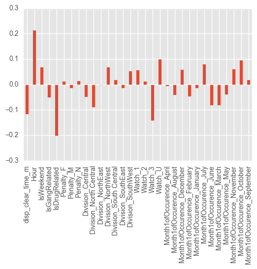

```python
# Plotting scaler variables for better view of the significant variables
from matplotlib import pyplot as plt
%matplotlib inline
plt.style.use('ggplot')

weights = pd.Series(lr_clf.coef_[0],index=df_imputed.columns)
weights.plot(kind='bar')
plt.show()
```

If we use a 0.1 threshold, we see that `IsDrugRelated`, `Hour`, `disp_clear_time_m`, `Watch_3`, and `Watch_U` all have the most weight in predicting `IsSlowtoDispatch`. However, `disp_clear_time_m` and `Watch_U` don't really make logical sense to keep in our model as `Watch_U` stands for unknown watch, which doesn't really give us any information, and the time the incident was cleared is probably highly correlated with our response variable of `IsSlowtoDispatch`. There is one more variable that may or may not be important and that's `Month1ofOccurrence_October` so before moving on, let's create another visualization that includes error bars to get more clarity on whether we should include this variable.

```python
from sklearn.preprocessing import StandardScaler
# Normalizing features based upon the mean and standard deviation of each column.

from sklearn.pipeline import Pipeline
# applying the StandardScaler function inside of the cross-validation loop
#    using the PipeLines in scikit

std_scl = StandardScaler()
lr_clf = LogisticRegression(penalty='l2', C=0.05)

# create the pipline
piped_object = Pipeline([('scale', std_scl),  # do this
                         ('logit_model', lr_clf)]) # and then do this

weights = []
# run the pipline cross validated
for iter_num, (train_indices, test_indices) in enumerate(cv_object.split(X,y)):
    piped_object.fit(X[train_indices],y[train_indices])  # train object
    # it is a little odd getting trained objects from a  pipeline:
    weights.append(piped_object.named_steps['logit_model'].coef_[0])


weights = np.array(weights)
```

```python
# Let's use a visual for the regression weights
import plotly
plotly.offline.init_notebook_mode() # run at the start of every notebook

error_y=dict(
            type='data',
            array=np.std(weights,axis=0),
            visible=True
        )

graph1 = {'x': df_imputed.columns,
          'y': np.mean(weights,axis=0),
    'error_y':error_y,
       'type': 'bar'}

fig = dict()
fig['data'] = [graph1]
fig['layout'] = {'title': 'Logistic Regression Weights, with error bars'}

plotly.offline.iplot(fig)
```

[interactive chart not shown]

Based on the graph above, it looks like it's safe to leave out `Month1ofOccurrence_October` and only keep the variables `Hour`, `Watch_3`, and `IsDrugRelated`. So we will **delete** the rest of the variables...

```python
# Narrowing down attributes and rerunning block

Xnew = df_imputed[['Hour','IsDrugRelated','Watch_3']].values

weights = []
# run the pipline corssvalidated
for iter_num, (train_indices, test_indices) in enumerate(cv_object.split(Xnew,y)):
    piped_object.fit(Xnew[train_indices],y[train_indices])  # train object
    weights.append(piped_object.named_steps['logit_model'].coef_[0])

weights = np.array(weights)

error_y=dict(
            type='data',
            array=np.std(weights,axis=0),
            visible=True
        )

graph1 = {'x': ['Hour','IsDrugRelated','Watch_3'],
          'y': np.mean(weights,axis=0),
    'error_y':error_y,
       'type': 'bar'}

fig = dict()
fig['data'] = [graph1]
fig['layout'] = {'title': 'Logistic Regression Weights, with error bars'}

plotly.offline.iplot(fig)
```

[interactive chart not shown]

`Hour` is the most important variable when it comes to determining a slow dispatch time, closely followed by `IsDrugRelated` and then `Watch_3` indicating fast dispatch times. It seems that the time of day, specifically what hour of the day is a great predictor in slower dispatch times. Breaking the `Hour` into groupings might be a better indicators for determining slower or faster dispatch times. Breaking the `Hour` into groups would be closely related to the `Watch` attributes. The `watch_1` attribute indicates slower dispatch times and `Watch_3` which indicates the overnight shift having faster dispatch times. There may be less activity during these hours that contribute to faster dispatch time. Lastly, drug related occurrences also have faster dispatch times. This value is negative so this may mean that if an incident is drug related, it negatively affects a slower dispatch time. Therefore, drug related incidents have faster dispatch times, if we interpreted this correctly.

Overall, the results of our logistic regression analysis on slow dispatch times show that the hour of the day, watch, and drug related incidents carry the most weight in prediction. We might be able to either remove the hour variable since this may overlap in the watch variables or break the hour into groups that could eliminate the watch variable.

Back to Top

# Support Vector Machines

Support Vector Machines are machine learning methods that rely upon kernel functions that work to classify observations into one or more classes. Using this approach we can attempt to predict classes for unknown data based upon the model created using training data.

```python
# Run cross validation loop setting the training and testing variables using
#     a single iteration
for train_indices, test_indices in cv_object.split(X,y):
    # Creating new variable again with the train and test

    X_train = X[train_indices]
    y_train = y[train_indices]

    X_test = X[test_indices]
    y_test = y[test_indices]

X_train_scaled = scl_obj.transform(X_train) # apply to training
X_test_scaled = scl_obj.transform(X_test)
```

```python
#  Running the SVM on the data and testing different cost and kernel parameters
#  Runs a long time on dataset
from sklearn.svm import SVC

# training model with support vector machine
svm_clf = SVC(C=1, kernel='linear', degree=3, gamma='auto') # get object
svm_clf.fit(X_train_scaled, y_train)  # train object

y_hat = svm_clf.predict(X_test_scaled) # get test set predictions

acc = mt.accuracy_score(y_test,y_hat)
conf = mt.confusion_matrix(y_test,y_hat)
print('accuracy:', acc )
print(conf)
```

```
accuracy: 0.724118831823
[[14381     0]
 [ 5479     0]]
```

Our results show an accuracy of 72%, which is what we have seen previously. However, the confusion matrix is a bit odd in that it contains two zeros. These zeros indicate that there were no true negatives and no false negatives. We adjusted the cost to 10 (not shown because it takes a long time to process), and the results are around the same- 72% accuracy and two zeros in the same place in the confusion matrix. We attempted to run `kernel = rbf` but after a long wait received an error. So, let's move on and take a closer look at our support vectors:

```python
# look at the support vectors
print(svm_clf.support_vectors_.shape)
print(svm_clf.support_.shape)
print(svm_clf.n_support_ )
```

```
(46012, 31)
(46012,)
[24016 21996]
```

```
[[  5.98255355e-07   4.11636528e-05   6.67674635e-06  -9.00436504e-06
   -2.04227927e-05   1.30359547e-05  -1.28479870e-05  -2.28688354e-06
    9.56914829e-06   7.59538364e-06   2.90760864e-06  -2.91661334e-05
    1.27003210e-05   1.47139931e-05  -1.64355953e-05   2.61445892e-05
    1.25223239e-05  -4.17984381e-05   3.62942569e-06  -2.23534256e-05
    3.44768836e-05   1.49071092e-05  -2.26835059e-05   1.44426700e-05
   -3.31997626e-07  -2.25663367e-05  -1.25389964e-05  -3.93155697e-05
    6.97619981e-06   7.60100465e-06   4.04890762e-05]]
```

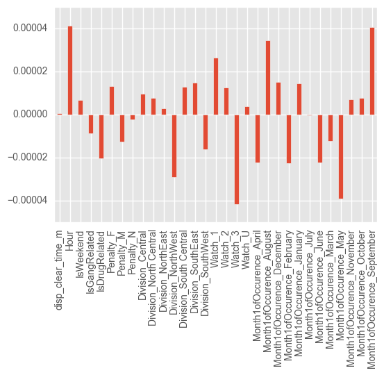

```python
# Taking a look at the linear kernel
print(svm_clf.coef_)
weights = pd.Series(svm_clf.coef_[0],index=df_imputed.columns)

weights.plot(kind='bar')
```

In both logistic regression and SVM anayses we see that Drug related crimes tend to have faster dispatch times. In addition, Watch 3 and crimes classified as misdemeanor and the month of May shows faster dispatch times in our SVM analysis. In contrast, the variables felony, Watch 1, and the months of August and September have slower dispatch times. The weights in our SVM analysis is mostly consistent with our expectations such as felonies with slower dispatch times and drug related crimes having a faster dispatch time.

```python
# Doing some different analysis with the SVM and looking at the instances that were chosen as support vectors

# make a dataframe of the training data
df_tested_on = df_imputed.loc[train_indices] # saved from above, the indices chosen for training
# now get the support vectors from the trained model
df_support = df_tested_on.loc[svm_clf.support_,:]

df_support['IsSlowtoDispatch'] = y[svm_clf.support_] # add back in the 'IsSlowtoDispatch' Column to the pandas dataframe
df_imputed['IsSlowtoDispatch'] = y # also add it back in for the original data
df_support.info()
```

```
<class 'pandas.core.frame.DataFrame'>
Int64Index: 46012 entries, 0 to 79435
Data columns (total 32 columns):
disp_clear_time_m              18122 non-null float64
Hour                           18122 non-null float64
IsWeekend                      18122 non-null float64
IsGangRelated                  18122 non-null float64
IsDrugRelated                  18122 non-null float64
Penalty_F                      18122 non-null float64
Penalty_M                      18122 non-null float64
Penalty_N                      18122 non-null float64
Division_Central               18122 non-null float64
Division_North Central         18122 non-null float64
Division_NorthEast             18122 non-null float64
Division_NorthWest             18122 non-null float64
Division_South Central         18122 non-null float64
Division_SouthEast             18122 non-null float64
Division_SouthWest             18122 non-null float64
Watch_1                        18122 non-null float64
Watch_2                        18122 non-null float64
Watch_3                        18122 non-null float64
Watch_U                        18122 non-null float64
Month1ofOccurence_April        18122 non-null float64
Month1ofOccurence_August       18122 non-null float64
Month1ofOccurence_December     18122 non-null float64
Month1ofOccurence_February     18122 non-null float64
Month1ofOccurence_January      18122 non-null float64
Month1ofOccurence_July         18122 non-null float64
Month1ofOccurence_June         18122 non-null float64
Month1ofOccurence_March        18122 non-null float64
Month1ofOccurence_May          18122 non-null float64
Month1ofOccurence_November     18122 non-null float64
Month1ofOccurence_October      18122 non-null float64
Month1ofOccurence_September    18122 non-null float64
IsSlowtoDispatch               46012 non-null int64
dtypes: float64(31), int64(1)
memory usage: 11.6 MB
```

```python
df_imputed.IsSlowtoDispatch = df_imputed.IsSlowtoDispatch.astype(np.float)
df_imputed.Hour = df_imputed.Hour.astype(np.float)
df_imputed.IsDrugRelated = df_imputed.IsDrugRelated.astype(np.float)
#df_imputed.info()
```

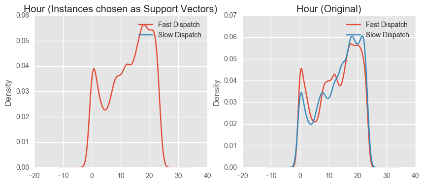

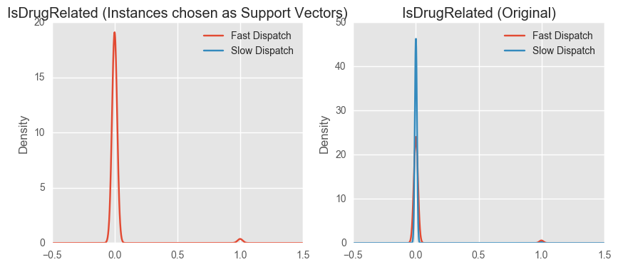

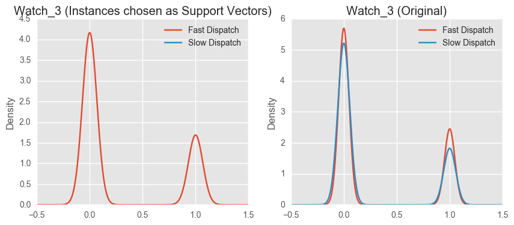

```python
# now lets see the statistics of these attributes
from pandas.tools.plotting import boxplot

# group the original data and the support vectors
df_grouped_support = df_support.groupby(['IsSlowtoDispatch'])
df_grouped = df_imputed.groupby(['IsSlowtoDispatch'])

# plot KDE of Different variables
vars_to_plot = ['Hour','IsDrugRelated','Watch_3']

for v in vars_to_plot:
    plt.figure(figsize=(10,4))
    # plot support vector stats
    plt.subplot(1,2,1)
    ax = df_grouped_support[v].plot.kde()
    plt.legend(['Fast Dispatch','Slow Dispatch'])
    plt.title(v+' (Instances chosen as Support Vectors)')

    # plot original distributions
    plt.subplot(1,2,2)
    ax = df_grouped[v].plot.kde()
    plt.legend(['Fast Dispatch','Slow Dispatch'])
    plt.title(v+' (Original)')
```

The graphs above show the original statistics of the data (right) versus the statistics of the support vectors (left). The separation in the original data is greater compared to those of the support vectors. The reason for this lies in the definition of support vectors as they are the instances on the edge of class boundaries (ie. right on the end of the margins) and tend to be those that are classified incorrectly as to maximize those margins.

Back to Top

# Gradient Based Alternatives

```python
# splitting the data in half for test and train using scikit learn StratifiedShuffleSplit
from sklearn.model_selection import StratifiedShuffleSplit

cv = StratifiedShuffleSplit( n_splits=1,test_size=0.5)
```

```python
# Using stochastic decent running a linear SVM classifier
from sklearn.linear_model import SGDClassifier

regularize_const = 0.000008
iterations = 10
svm_sgd = SGDClassifier(alpha=regularize_const,
        fit_intercept=True, l1_ratio=0.0, learning_rate='optimal',
        loss='log', n_iter=iterations, n_jobs=-1, penalty='l2')

scl = StandardScaler()
for train_idx, test_idx in cv.split(X,y):
    svm_sgd.fit(scl.fit_transform(X[train_idx]),y[train_idx])
    yhat = svm_sgd.predict(scl.transform(X[test_idx]))

    conf = mt.confusion_matrix(y[test_idx],yhat)
    acc = mt.accuracy_score(y[test_idx],yhat)

print('SVM:', acc)
print(conf)
```

```
SVM: 0.618232355785
[[25557 10353]
 [ 8601  5137]]
```

```python
# Using stochastic decent running a logistic regression classifier setting up object parameters
log_sgd = SGDClassifier(alpha=regularize_const,
        fit_intercept=True, l1_ratio=0.0, learning_rate='optimal',
        loss='log', n_iter=iterations, n_jobs=-1, penalty='l2')

scl = StandardScaler()
for train_idx, test_idx in cv.split(X,y):
    log_sgd.fit(scl.fit_transform(X[train_idx]),y[train_idx])
    yhat = log_sgd.predict(scl.transform(X[test_idx]))

    conf = mt.confusion_matrix(y[test_idx],yhat)
    acc = mt.accuracy_score(y[test_idx],yhat)

print('Logistic Regression:', acc)
print(conf)
```

```
Logistic Regression: 0.606127135031
[[25451 10460]
 [ 9095  4642]]
```

```python
# Trying a principal component analysis
# now lets use some of what we know from this class to reduce the dimensionality of the set
from sklearn.decomposition import PCA
n_components = 21

pca = PCA(n_components=n_components, svd_solver='randomized')

iterations = 150
log_sgd = SGDClassifier(
        fit_intercept=True, l1_ratio=0.0, learning_rate='optimal',
        loss='log', n_iter=iterations, n_jobs=-1, penalty='l2')

# you could also set this up in a pipeline
for train_idx, test_idx in cv.split(X,y):
    log_sgd.fit(pca.fit_transform(X[train_idx]),y[train_idx])
    yhat = log_sgd.predict(pca.transform(X[test_idx]))

    conf = mt.confusion_matrix(y[test_idx],yhat)
    acc = mt.accuracy_score(y[test_idx],yhat)

print('Principal Components', acc)
print('Confusion Matrix',conf)
```

```
Principal Components 0.629209635836
Confusion Matrix [[30229  5682]
 [12727  1010]]
```

Back to Top

# Conclusion

The results of our logistic regression are that the variables `Hour`, `Watch_3`, and `IsDrugRelated` were important in predicting a slow dispatch time. We expected to see maybe a slower dispatch time in certain areas or divisions and possibly certain months of the year as weather may have an effect but didn't see that affect our final model. For further research, also looking at what factors affect a fast response time would be interesting. Other research directions could be to explore dispatch time prediction for specific crimes such as Theft which was the highest occuring crime in Dallas. Focusing on one type of crime would reduce noise in our dataset and allow for more meaningful interpretation of our models. This would inform stakeholders of what were the drivers of slow dispatch time for specific types of crime and even be refined to specific types of crime in specific communities.

Finally, to further explore the relationship between dispatch time and our predictors we included some jointplots to visualize dispatch time as a continuous variable and plotting it against longitudinal and latitudinal variables.

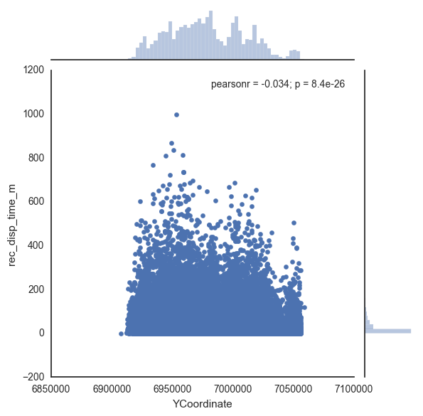

```python
import numpy as np, pandas as pd; np.random.seed(0)
import seaborn as sns; sns.set(style="white", color_codes=True)
g = sns.jointplot(y="rec_disp_time_m", x="YCoordinate", data=df_Plot)
```

In this plot we can see that the majority of dispatch times are less than 5 minute

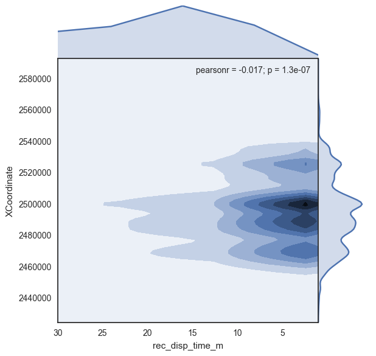

```python
g = sns.jointplot("rec_disp_time_m", "XCoordinate", data=df_Plot,kind="kde", space=0, color="b",xlim=30)
```

In this plot we see that there is a greater concentration of crimes in the east than in the west ( as X coordinates increase we go further west from city center) We also see that variance in dispatch time is greater in the east than the west). Further analyses with crime specific datasets would be helpful in observing describing the relationship between geographic region and dispatch time. This subset analysis will reduce the noise in our analysis and allow for more interpretable results

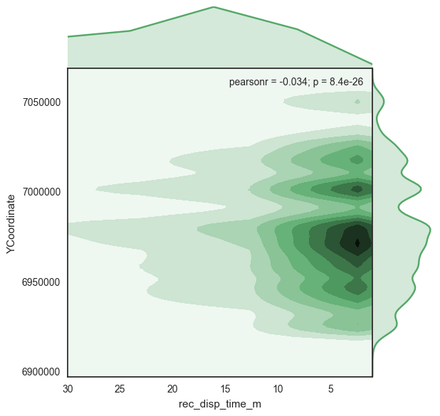

```python
g = sns.jointplot("rec_disp_time_m", "YCoordinate", data=df_Plot,kind="kde", space=0, color="g",xlim=30)
```

In the joint plot pasted above we see that observations are clustered in the city center and slightly north of the city center Also of interest is that observations are clustered at the lower end of the distribution of dispatch times. In the joint plot above we can see that the further crimes are from the city center the longer the dispatch time will be. However, it is impotant to note that the greatest extremes in dispatch variance are also observed in the city center. we may infer that the high volume of crimes and limited resources at city center prevent officers from attending to cases in a timely manner for all cases.